# `cellranger` mapping statistics

Arun Chavan

Started: 2020-11-17  
Last edited: 2020-12-07 10:43:49

```r
library(knitr)
knitr::opts_chunk$set(dpi = 300)
```

```r
library(tidyverse)
library(patchwork)
library(kableExtra)
library(ggthemes)
```

# 1 Overview

## 1.1 Samples

The samples come from different animals:

| sample | animal | cell/ul | volume loaded | cells loaded |
| --- | --- | --- | --- | --- |
| bflo_pharynx | bflo_61 | 680 | 22 ul | 14960 |
| bflo_midgut | bflo_61 | 1040 | 22 ul | 22880 |
| bflo_hindgut | bflo_69 | 360 | 22 ul | 7920 |

## 1.2 Input FASTQ files

For each sample there are 3 files: left read, right read, and index.

|  | Read 1 | i7 Index | i5 Index | Read 2 |
| --- | --- | --- | --- | --- |
| *Purpose* | Cell barcode & UMI | Sample Index | N/A | Insert |
| *Length* | 28 | 8 | 0 | 91 |

For example:

```
bflo_pharynx_OTH_S1_L003_I1_001.fastq.gz
bflo_pharynx_OTH_S1_L003_R1_001.fastq.gz
bflo_pharynx_OTH_S1_L003_R2_001.fastq.gz
```

## 1.3 Genomes

The data were aligned to the following genome assemblies:

1. Genbank GCA_000003815.1_Version_2
2. Genbank GCA_000003815.1_Version_2_with-mito
3. BfsuperV5
4. ensembl BraLan2 (*lanceolatum*, not *floridae*)
5. Refseq GCF_000003815.2_Bfl_VNyyk

# 2 Summary stats

## 2.1 Compile metrics from `cellranger` output

```r
## function for reading and parsing files
readMetric <- function(run, sample){
  assign("df",
         read.csv(paste0("../../",
                         run,
                         "/data/02_cellranger-count",
                         "/bflo_", sample,
                         "/outs/metrics_summary.csv")) %>%
           t() %>% # transpose
           as.data.frame())
  df[, 'metric'] <- row.names(df)
  df$metric.type <- NA # assigns metrics to categories, e.g. sequencing, mapping
  df$metric.type[
    which(df$metric %in%
            c("Number.of.Reads", "Valid.Barcodes", "Valid.UMIs",
              "Sequencing.Saturation", "Q30.Bases.in.Barcode",
              "Q30.Bases.in.RNA.Read", "Q30.Bases.in.Sample.Index",
              "Q30.Bases.in.UMI"))] <-  "Sequencing"
  df$metric.type[
    which(df$metric %in%
            c("Reads.Mapped.to.Genome", "Reads.Mapped.Confidently.to.Genome",
              "Reads.Mapped.Confidently.to.Intergenic.Regions",
              "Reads.Mapped.Confidently.to.Intronic.Regions",
              "Reads.Mapped.Confidently.to.Exonic.Regions",
              "Reads.Mapped.Confidently.to.Transcriptome",
              "Reads.Mapped.Antisense.to.Gene"))] <-  "Mapping"
  df$metric.type[
    which(df$metric %in%
            c("Estimated.Number.of.Cells", "Fraction.Reads.in.Cells",
              "Mean.Reads.per.Cell", "Median.Genes.per.Cell",
              "Total.Genes.Detected", "Median.UMI.Counts.per.Cell"))] <-  "Cells"

  df[, paste0(run, "___", sample)] <- df[, "V1"]
  row.names(df) <- NULL
  df[, "V1"] <- NULL
  df
}
```

```r
# define runs and samples
runs <- c("ensembl__BraLan2",
          "BfsuperV5",
          "genbank__GCA_000003815.1_Version_2",
          "genbank__GCA_000003815.1_Version_2_with-mito",
          "refseq__GCF_000003815.2_Bfl_VNyyK")
samples <- c("pharynx", "midgut", "hindgut")
```

```r
# read files
met <- list()
for (i in runs){
  for (j in samples){
    met[[i]][[j]] <- readMetric(run = i, sample = j)
  }
}
```

```r
# merge files
sumstats <- map(met,
                function(x) {
                  purrr::reduce(x, inner_join, by = c("metric", "metric.type"))
                }) %>%
  purrr::reduce(inner_join, by = c("metric", "metric.type"))

# reorder
sumstats$metric.type <- factor(sumstats$metric.type,
                               levels = c("Sequencing", "Mapping", "Cells"))
sumstats <- sumstats[order(sumstats$metric.type), ]
sumstats$metric <- factor(sumstats$metric, levels = sumstats$metric)

# save
write.csv(sumstats, "../results/02_cellranger-stats/cellranger_summary-stats.csv", row.names = FALSE)
```

## 2.2 Table

```r
kable(sumstats[, c(1,3:17)],
      col.names = c("metric", rep(c("pharynx", "midgut", "hindgut"), 5)),
      caption = "Cellranger summary stats",
      align = c("lrrrrrrrrrrrrrrr")) %>%
  kable_styling(bootstrap_options = c("striped", "hover", "condensed", "responsive"),
                font_size = 10, fixed_thead = TRUE) %>%
  add_header_above(c(" " = 2, # need to add an extra because df has rownames column
                     "ensembl__BraLan2" = 3,
                     "BfsuperV5" = 3,
                     "genbank__GCA_000003815.1_Version_2" = 3,
                     "genbank__GCA_000003815.1_Version_2_with-mito" = 3,
                     "refseq__GCF_000003815.2_Bfl_VNyyK" = 3)) %>%
  pack_rows("Sequencing", 1, 7) %>%
  pack_rows("Mapping", 8, 14) %>%
  pack_rows("Cells", 15, 19) %>%
  footnote(general = "Most metrics with values between 0 and 100 are in percentages. Most other metrics are numbers. If in doubt, check the original output files.")
```

Cellranger summary stats

|  | metric | ensembl__BraLan2 pharynx | ensembl__BraLan2 midgut | ensembl__BraLan2 hindgut | BfsuperV5 pharynx | BfsuperV5 midgut | BfsuperV5 hindgut | genbank__GCA_000003815.1_Version_2 pharynx | genbank__GCA_000003815.1_Version_2 midgut | genbank__GCA_000003815.1_Version_2 hindgut | genbank__GCA_000003815.1_Version_2_with-mito pharynx | genbank__GCA_000003815.1_Version_2_with-mito midgut | genbank__GCA_000003815.1_Version_2_with-mito hindgut | refseq__GCF_000003815.2_Bfl_VNyyK pharynx | refseq__GCF_000003815.2_Bfl_VNyyK midgut | refseq__GCF_000003815.2_Bfl_VNyyK hindgut |
| --- | --- | --- | --- | --- | --- | --- | --- | --- | --- | --- | --- | --- | --- | --- | --- | --- |
| **Sequencing** |  |  |  |  |  |  |  |  |  |  |  |  |  |  |  |  |
| 4 | Number.of.Reads | 258,610,764 | 307,675,970 | 266,405,488 | 258,610,764 | 307,675,970 | 266,405,488 | 258,610,764 | 307,675,970 | 266,405,488 | 258,610,764 | 307,675,970 | 266,405,488 | 258,610,764 | 307,675,970 | 266,405,488 |
| 5 | Valid.Barcodes | 97.4% | 96.8% | 98.0% | 97.4% | 96.8% | 98.0% | 97.4% | 96.8% | 98.0% | 97.4% | 96.8% | 98.0% | 97.4% | 96.8% | 98.0% |
| 6 | Sequencing.Saturation | 83.3% | 85.4% | 86.4% | 78.4% | 80.9% | 83.5% | 85.5% | 87.4% | 89.3% | 85.5% | 87.8% | 89.3% | 85.4% | 87.5% | 90.0% |
| 7 | Q30.Bases.in.Barcode | 97.1% | 97.1% | 97.1% | 97.1% | 97.1% | 97.1% | 97.1% | 97.1% | 97.1% | 97.1% | 97.1% | 97.1% | 97.1% | 97.1% | 97.1% |
| 8 | Q30.Bases.in.RNA.Read | 95.0% | 94.7% | 95.4% | 95.0% | 94.7% | 95.4% | 95.0% | 94.7% | 95.4% | 95.0% | 94.7% | 95.4% | 95.0% | 94.7% | 95.4% |
| 9 | Q30.Bases.in.UMI | 96.9% | 96.9% | 96.9% | 96.9% | 96.9% | 96.9% | 96.9% | 96.9% | 96.9% | 96.9% | 96.9% | 96.9% | 96.9% | 96.9% | 96.9% |
| 10 | Reads.Mapped.to.Genome | 31.4% | 32.1% | 35.9% | 81.2% | 84.5% | 87.3% | 69.5% | 68.0% | 74.6% | 75.6% | 77.7% | 79.0% | 78.2% | 82.5% | 83.5% |
| **Mapping** |  |  |  |  |  |  |  |  |  |  |  |  |  |  |  |  |
| 11 | Reads.Mapped.Confidently.to.Genome | 30.0% | 28.4% | 34.7% | 52.8% | 50.8% | 57.7% | 65.4% | 61.3% | 70.2% | 71.5% | 71.0% | 74.6% | 74.5% | 74.8% | 80.9% |
| 12 | Reads.Mapped.Confidently.to.Intergenic.Regions | 5.4% | 4.7% | 5.5% | 3.6% | 4.1% | 2.3% | 24.9% | 21.0% | 19.0% | 24.9% | 21.0% | 19.0% | 6.5% | 7.4% | 5.3% |
| 13 | Reads.Mapped.Confidently.to.Intronic.Regions | 0.5% | 0.5% | 0.4% | 0.9% | 1.2% | 1.9% | 6.5% | 4.7% | 6.5% | 6.5% | 4.7% | 6.5% | 3.8% | 2.4% | 2.2% |
| 14 | Reads.Mapped.Confidently.to.Exonic.Regions | 24.1% | 23.1% | 28.8% | 48.3% | 45.4% | 53.4% | 34.0% | 35.6% | 44.7% | 40.0% | 45.4% | 49.1% | 64.3% | 65.0% | 73.4% |
| 15 | Reads.Mapped.Confidently.to.Transcriptome | 21.1% | 20.5% | 25.2% | 30.0% | 28.4% | 34.4% | 30.5% | 32.2% | 40.2% | 36.4% | 41.7% | 44.4% | 61.1% | 62.0% | 70.5% |
| 16 | Reads.Mapped.Antisense.to.Gene | 0.2% | 0.2% | 0.3% | 2.2% | 1.8% | 1.8% | 0.5% | 0.4% | 0.3% | 0.5% | 0.4% | 0.3% | 1.3% | 1.1% | 0.7% |
| 1 | Estimated.Number.of.Cells | 1,121 | 582 | 1,340 | 1,840 | 876 | 1,941 | 1,274 | 719 | 1,601 | 1,410 | 1,345 | 1,740 | 2,406 | 1,874 | 2,544 |
| **Cells** |  |  |  |  |  |  |  |  |  |  |  |  |  |  |  |  |
| 2 | Mean.Reads.per.Cell | 230,696 | 528,652 | 198,810 | 140,549 | 351,228 | 137,251 | 202,991 | 427,922 | 166,399 | 183,411 | 228,755 | 153,106 | 107,485 | 164,181 | 104,719 |
| 3 | Median.Genes.per.Cell | 556 | 471 | 407 | 798 | 919 | 617 | 646 | 544 | 440 | 588 | 280 | 414 | 659 | 386 | 516 |
| 17 | Fraction.Reads.in.Cells | 61.6% | 38.3% | 48.4% | 67.3% | 41.5% | 51.9% | 63.9% | 43.6% | 50.4% | 62.6% | 41.7% | 49.0% | 67.1% | 43.0% | 52.8% |
| 18 | Total.Genes.Detected | 16,840 | 14,360 | 14,002 | 78,442 | 60,090 | 55,146 | 17,419 | 15,223 | 14,797 | 17,487 | 15,360 | 14,910 | 21,303 | 19,281 | 18,618 |
| 19 | Median.UMI.Counts.per.Cell | 2,003 | 2,127 | 1,607 | 1,533 | 2,162 | 1,430 | 1,959 | 2,281 | 1,542 | 1,949 | 1,099 | 1,469 | 1,400 | 994 | 1,268 |

Note:  
Most metrics with values between 0 and 100 are in percentages. Most other metrics are numbers. If in doubt, check the original output files.

## 2.3 Plots

```r
## get data in shape
sumstats[, 3:17] <- apply(sumstats[,3:17], 2,
                          function(y) as.numeric(gsub("[%,]", "", y))) # remove % symbol and , and turn the values into numerics

sumstats.long <- pivot_longer(data = sumstats,  cols = 3:17,
                              names_to = c('run','sample'), values_to = 'value',
                              names_sep = '___') %>%
  as.data.frame()

metrics <- unique(sumstats.long$metric)
metric.percent <- c(2, 3, 4, 5, 6, 7, 8, 9, 10, 11, 12, 13, 17)
metric.number <- c(1, 14, 15, 16, 18, 19)
```

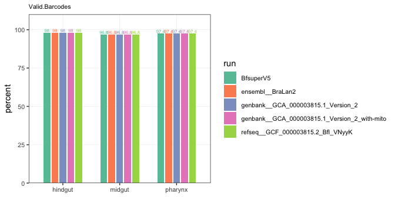

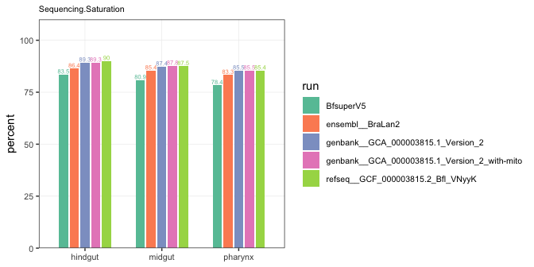

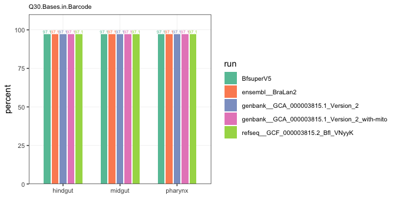

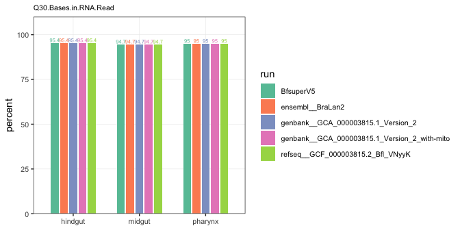

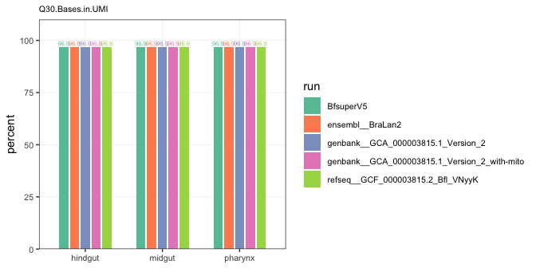

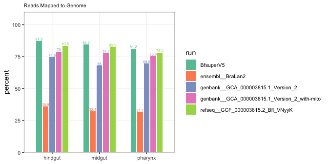

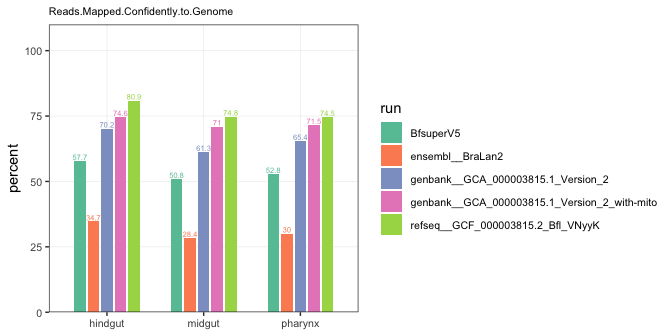

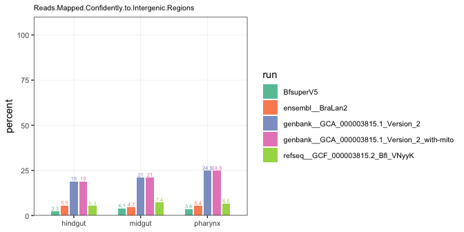

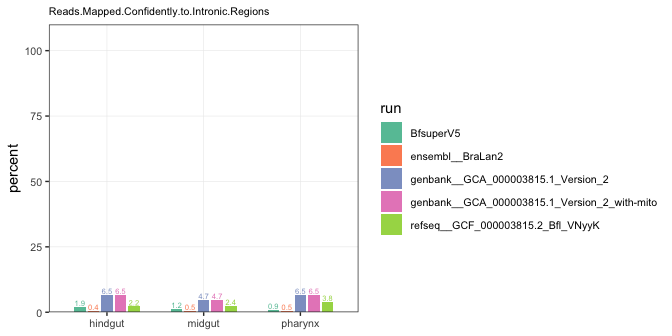

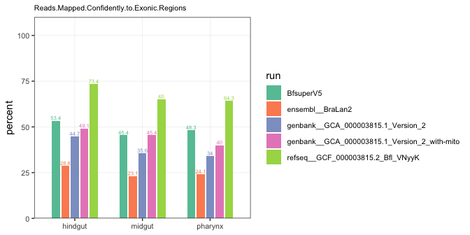

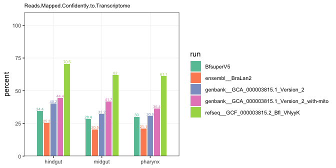

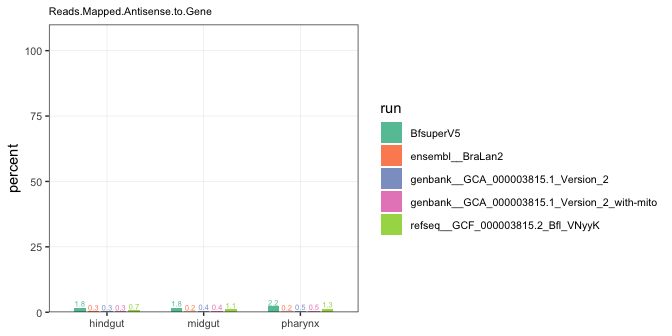

[1 more figures not shown]

```r
## plot: percent metrics
# function
percentPlot <- function(dat){
  p <- ggplot(data = dat) +
    geom_col(aes(x = sample, y = value, fill = run),
             width = 0.6,
             position = position_dodge(width = 0.7)) +
    geom_text(mapping = aes(x = sample, y = value, colour = run,
                            label = round(value, 1)),
              position = position_dodge(width = 0.7), vjust = -0.25, size = 2) +
    scale_fill_brewer(palette = "Set2") +
    scale_color_brewer(palette = "Set2") +
    scale_y_continuous(limits = c(0,110),
                       expand = c(0,0)) + # for percents
    ylab("percent") +
    theme_bw() +
    theme(axis.title.x = element_blank(),
          axis.text = element_text(size = 8),
          legend.background = element_blank(),
          plot.background = element_blank(),
          panel.grid.minor = element_blank(),
          panel.grid.major = element_line(size = 0.2),
          legend.text = element_text(size = 8),
          plot.title = element_text(size = 8)) +
    ggtitle(pmetric)
  ggsave(p, filename = paste0(pmetric, ".pdf"), path = "../results/02_cellranger-stats/", width = 6, height = 3, units = 'in')
  print(p)
}

for(i in 1:length(metric.percent)){
  pmetric <- metrics[metric.percent[i]]
  percentPlot(dat = sumstats.long[sumstats.long$metric == pmetric, ])
}
```

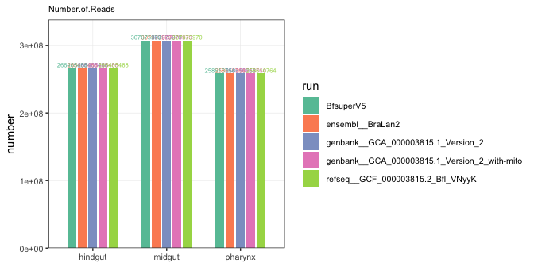

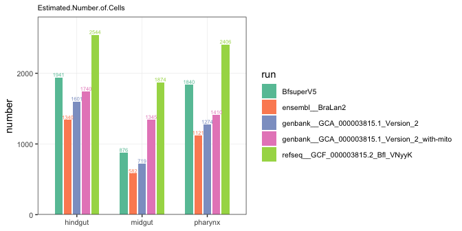

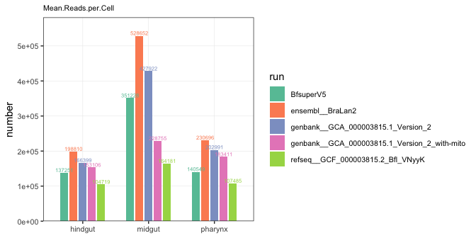

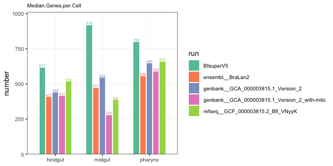

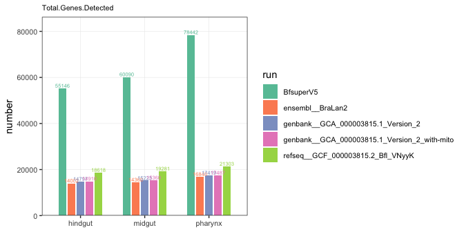

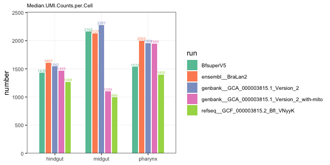

```r
## plot number metrics
# function
numberPlot <- function(dat){
  p <- ggplot(data = dat) +
    geom_col(aes(x = sample, y = value, fill = run),
             width = 0.6,
             position = position_dodge(width = 0.7)) +
    geom_text(mapping = aes(x = sample, y = value, colour = run,
                            label = round(value, 1)),
              position = position_dodge(width = 0.7), vjust = -0.25, size = 2) +
    scale_fill_brewer(palette = "Set2") +
    scale_color_brewer(palette = "Set2") +
    scale_y_continuous(
      limits = c(0,
               max(sumstats.long[sumstats.long$metric == pmetric, 'value']) * 1.1),
      expand = c(0,0)) +
    ylab('number') +
    theme_bw() +
    theme(axis.title.x = element_blank(),
          axis.text = element_text(size = 8),
          legend.background = element_blank(),
          plot.background = element_blank(),
          panel.grid.minor = element_blank(),
          panel.grid.major = element_line(size = 0.2),
          legend.text = element_text(size = 8),
          plot.title = element_text(size = 8)) +
    ggtitle(pmetric)
  ggsave(p, filename = paste0(pmetric, ".pdf"), path = "../results/02_cellranger-stats/", width = 6, height = 3, units = 'in')
  print(p)
}

# plot metrics with numbers as units
for(i in 1:length(metric.number)){
  pmetric <- metrics[metric.number[i]]
  numberPlot(dat = sumstats.long[sumstats.long$metric == pmetric, ])
}
```